# Parallel R

2017-10-18

## Today's Agenda

- Review vector and matrix math
- Review the apply family of functions
- Discuss methods to make things faster
  - foreach
  - doParallel (SNOW-multicore)
  - parxxApply
  - Rmpi
- Homework 7

## vectors and matrices in R

Super easy to create:

```r
a <- c(1:5)
B <- matrix(1:10, ncol = 2)
a
B
```

## basic operations

- add, multiply vector/matrix by a scalar
- add, multiply vectors/matrix

And all the vector/matrix operations we would expect:

- transpose of vector/matrix
- multiply vector/matrix
- some special operations
  - diag (2 forms)
  - solve
  - trace
  - determinant
  - Kronecker product

## Using duality to do stuff

colMeans. What if we want the means of a matrix by columns. Of course there are functions for this, but, for kicks, can we do this with some mixed matrix art … ??

```r
colMeans(C)
ones <- rep(1, 3)
t(ones) %*% (C/3)
```

## Making things faster:

A lot of effort has gone into making matrix math faster on computers. Hopefully this sparks your curiousity enough to hit google:

```r
    A = matrix(rnorm(20*40000, mean=0, sd=5), 20, 40000)
    B = matrix(rnorm(20*40000, mean=0, sd=5), 20, 40000)
    system.time({t(A)%*%B})
    system.time({crossprod(A,B)})
```

Don't invert matrices:

https://www.johndcook.com/blog/2010/01/19/dont-invert-that-matrix/ https://www.r-bloggers.com/dont-invert-that-matrix-why-and-how/

```r
    n <- 5000
    A = matrix(rnorm(n*n, mean=0, sd=5), n, n)
    x <- rnorm(n)
    system.time({b_inverting <- solve(A)%*%x})
    system.time({b_solving <- solve(A,x)})

    max(abs(b_inverting - b_solving))
```

## Apply family of functions

In R, we have helper functions to further simplify our code by obviating the for loop.

Apply family:

apply, lapply , sapply, vapply, mapply, rapply, and tapply

Nice tutorial:  
https://www.r-bloggers.com/r-tutorial-on-the-apply-family-of-functions/

## Apply detail

*apply(X, MARGIN, FUN, …)*

```r
# ?apply
x <- cbind(x1 = 3, x2 = c(4:1, 2:5))
dimnames(x)[[1]] <- letters[1:8]
x
apply(x, 2, mean, trim = 0.2)
col.sums <- apply(x, 2, sum)
row.sums <- apply(x, 1, sum)

coinToss <- function(x) {
    rbinom(10, 1, x)
}
sapply(c(30:40)/100, FUN = coinToss)
```

## What is difference between various apply functions

We could start with the help `?apply, ?sapply`. The main differences are:  
http://www.dummies.com/programming/r/how-to-use-the-apply-family-of-functions-in-r/

## Apply functions

| Function Name | Objects the Function Works On | What the Function Sees as Elements | Result Type |
| --- | --- | --- | --- |
| apply | Matrix | Rows or columns | Vector, matrix, array, or list |
|  | Array | Rows, columns, or any dimension | Vector, matrix, array, or list |
|  | Data frame | Rows or columns | Vector, matrix, array, or list |
| sapply | Vector | Elements | Vector, matrix, or list |
|  | Data frame | Variables | Vector, matrix, or list |
|  | List | Elements | Vector, matrix, or list |
| lapply | Vector | Elements | List |
|  | Data frame | Variables | List |
|  | List | Elements | List |

## Summary

We have in our tool belt:

- for loops
- matrix ops
- apply functions

Now we need methods to make things faster. We discussed some methods around matrix operations. What if we can't (easily) convert to matrix operations?

## Example

```r
    set.seed(1245)
    n <- 30; B <- 100
    data <- 6 + rt(n, df = 1)
    tans <- rep(NA,B)
    system.time({
    for(b in 1:B){
        tans[b] <- sum(atan(1:5e6))
    }
    })
    calc_centers <- function(){
        sum(atan(1:5e6))
    }
    system.time({
    tans <- sapply(1:B,function(n) calc_centers(),
                      USE.NAMES = F)
    })
```

## foreach

How do we make this faster? Crank up B and take a look at the useage of the various cores in the computer…

Perhaps we need to use more of our computer.

First, the for loop…

```r
library(foreach)
system.time({
    tans <- foreach(b = 1:B, .combine = "c") %do% {
        sum(atan(1:5e+06))
    }
})
```

## foreach

```r
library(foreach)
library(doParallel)
system.time({
    tans <- foreach(b = 1:B, .combine = "c") %dopar% {
        sum(atan(1:5e+06))
    }
})
# cl <- makeCluster(ncores=6)
registerDoParallel(cores = 6)
system.time({
    tans <- foreach(b = 1:B, .combine = "c") %dopar% {
        sum(atan(1:5e+06))
    }
})
stopImplicitCluster()
# stopCluster(cl)
```

## parXXapply

Ok, so we can do some fun stuff with for loops, what about parallelizing the apply functions??

```r
    #library(doParallel)
    library(parallel)
    set.seed(1245)
    n <- 30; B <- 100
    data <- 6 + rt(n, df = 1)
    tans <- rep(NA,B)
    system.time({
    for(b in 1:B){
        tans[b] <- sum(atan(1:5e6))
    }
    })
    calc_centers <- function(){
        sum(atan(1:5e6))
    }

    cl <- makeCluster(6)
    clusterExport(cl,"calc_centers")
    system.time({
        tans <- parSapply(cl, 1:B,
                function(n) calc_centers(),USE.NAMES = F)
    })
    stopCluster(cl)
```

## Quick reminder on RNG

Remember, we often need random numbers. We need them different on different workers and we need them reproducible.

```r
    library(foreach)
    library(doParallel)
    library("doRNG")
    cl <- makeCluster(2); registerDoParallel(cl)

    set.seed(123)
    res <- foreach(i=1:5) %dopar% { runif(3) }
    set.seed(123)
    res2 <- foreach(i=1:5) %dopar% { runif(3) }
    identical(res, res2)

    registerDoRNG()
    set.seed(123)
    res <- foreach(i=1:5) %dopar% { runif(3) }
    set.seed(123)
    res2 <- foreach(i=1:5) %dopar% { runif(3) }
    identical(res, res2)

    stopCluster(cl)
```

## Regroup

What have we done?

Essentially, we have created a small cluster and run the same command across the cluster (SNOW). What if we need to update the progress of one "worker" to other workers??

http://www.glennklockwood.com/data-intensive/r/lapply-parallelism.html https://portal.tacc.utexas.edu/documents/13601/901835/Parallel_R_Final.pdf/eaa55f54-3e3a-4a96-be95-1f4de44fa119

## MPI

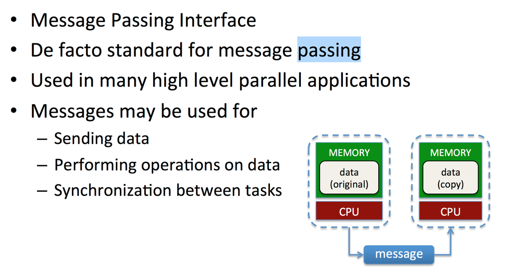

## MPI: Program Models

- "Brute Force": Decompose problem
- "Task Push": Master creates list of tasks and sends to slaves in round-robin fashion
- "Task Pull": Slaves report to master when finished, receive new tasks

Examples:

http://cran.r-project.org/web/packages/pbdMPI/vigneIes/pbdMPI-guide.pdf

## Rmpi

- User-developed package
- Interfce to MPI for R +Master/slave paradigm
- Allows parallelism beyond embarrassingly parallel, e.g. SNOW
- Provided as part of ARC R module

## Rmpi: Starting and Stopping

- Load library: library(Rmpi)
- Spawn nsl slaves mpi.spawn.Rslaves(nslaves=nsl)
- Shut down slaves (IMPORTANT) mpi.close.Rslaves()
- Clean up and quit R mpi.quit()

## Rmpi basics

- Run an Rmpi script like any other R script: Rscript mcpi_rmpi.r
- Get the number of processes (the number of slaves +1) mpi.comm.size()
- Get the rank of a process: mpi.comm.rank() + Mater: 0 - Slave: 1+

## Rmpi: Executing Remotely

```r
#Execute on the master:
paste("I am",mpi.comm.rank(),"of",mpi.comm.size())
   [1] "I am 0 of 3"

#Execute Rcommand on the slaves:
mpi.bcast.cmd(Rcommand)

#Execute on the slaves and return to master:
result <- mpi.remote.exec(Rcommand)

#Returns nslaves-length list
```

## Rmpi: Hello World

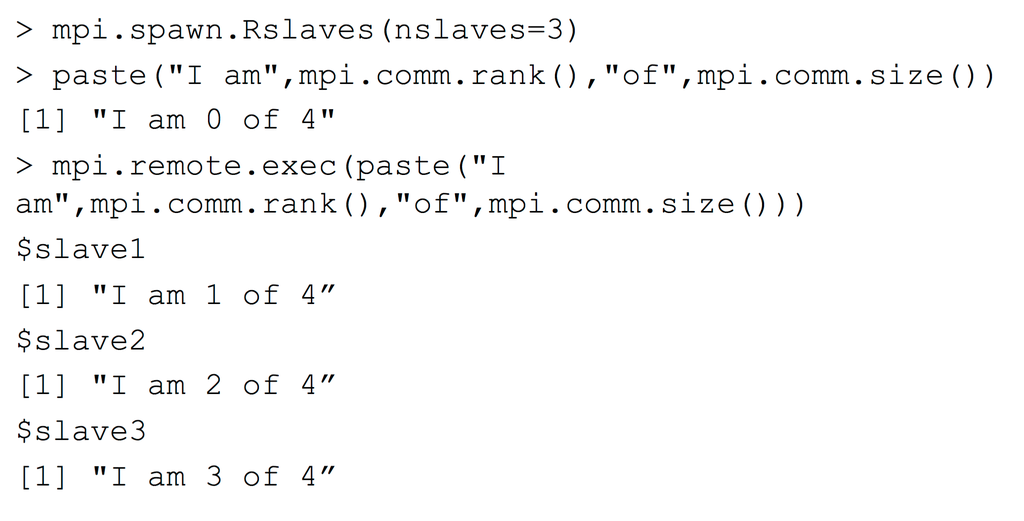

## Rmpi communications

- Broadcast a function or variable from mater to slave mpi.bcast.Robj2slave(object)
- Send object to destination mpi.send.Robj(object, destination, tag)
- Receive a sent message recv <- mpi.recv.Robj(mpi.any.source(),mpi.any.tag())
- Get tag from received message recv.info <- mpi.get.sourcetag()

## Rmpi Example: Pass messages

```r
# Function to pass message to next slave
message.pass <- function() {
    # Get each slave's rank
    myrank <- mpi.comm.rank()
    # Get partner slave's rank (some hackery to avoid
    # master)
    otherrank <- (myrank + 1)%%mpi.comm.size()
    otherrank <- otherrank + (otherrank == 0)
    # Send a message to the partner
    mpi.send.Robj(paste("I am rank", myrank), dest = otherrank,
        tag = myrank)
    # Receive the message & tag (includes source)
    recv.msg <- mpi.recv.Robj(mpi.any.source(), mpi.any.tag())
    recv.tag <- mpi.get.sourcetag()
    paste("Received message '", recv.msg, "' from process ",
        recv.tag[1], ".
\n", sep = "")
}
```

## Homework 7